# Data Analysis

Author

Vikram Vijayabaskar

# Introduction

## Introducing the data

The data set I will be using is the Pokemon Go evolution data set. It includes 75 Pokemon evolutions (across 4 species) and around 27 variables, as well as information about each Pokemon before and after evolution (combat power, hit points, size, power up costs, etc). Evolution in Pokemon means a Pokemon is growing stronger, thus, in this project, I’ll be analyzing/predicting post evolution combat power.

## Code Book

(All descriptions are from the readme attached to the data set)

| Variable | Description | Why it is used |
| --- | --- | --- |
| `species` | The Pokémon’s type, e.g. Pidgey. | I use this variable to compare whether CP (combat power) differs between species |
| `cp` | Pre-evolution Combat Power, which is a summary of the Pokémon’s strength for battling prior to the evolution of the Pokémon. | This is the main variable I will be using to predict. |
| `cp_new` | Post-evolution Combat Power. | This is the main variable I will be PREDICTING. |
| `hp` | Pre-evolution Hit Points, which is a summary of how difficult it is to weaken the Pokémon in a battle. | I use this variable for background summary statistics |
| `hp_new` | Post-evolution Hit Points. | I use this for comparing background statistics after evolution. |

## Omitted Variables

I will not be omitting any variables from the data set, HOWEVER, my main model will only be focusing on the variables that directly answer my research question. The model focuses on `cp_new`, `cp`, and the other variables left in the code book. Other variables in the data set such as `attack`, `attack types`, `weight`, `height`, and more aren’t included in the main regression model because they are not integral to our research question and might skew the data.

## Motivation

As a kid growing up with Pokemon because of an older brother, who was much more fascinated by the stats of Pokemon because he wanted the strongest team possible, I was interested in being able to predict whether or not I can tell a Pokemon is going to have a strong evolution simply based off its pre-evolution, therefore (even though I personally don’t play Pokemon anymore) I could decide which Pokemon I would want based off their pre-evolution and end up with the strongest team I could have. Some background information that suggests that there’s reason to investigate this is because sometimes some Pokemon have very weak pre-evolutions that evolve into very strong Pokemon, I want to be able to predict that.

## Research Question

My research question is: Can we predict a Pokemon’s post evolution combat power using it’s pre-evolution combat power, and does this relationship differ by species?

## Hypothesis

My hypotheses are

$H_0$ - Pre-evolution Combat Power is not associated with Post-Evolution Combat Power.

$H_A$ - Higher Pre-Evolution Combat Power is associated with higher Post-Evolution Combat Power.

# Methods

## Preliminary Summaries

Before diving into models, I will summarize the data by finding the total sample size, the number of variables, and summary statistics for the main outcome, which is the variable `cp_new`. I will also find the number of Pokemon in each `species` group. This shows how much data is available for each each species before comparing models

## Main Model

The main method I will be using for this project/analysis is linear regression.

$cp\_new = \beta_0 + \beta_1cp + \beta_2species + \beta_3(cp \times species) + \epsilon$

This model lets me test whether pre-evolution CP is associated with post-evolution CP while also accounting for differences between Pokemon species.

## Main Figure

The main figure of this analysis will be a scatter plot of `cp_new` versus `cp`, colored by `species`, with a fitted regression line. This figure shows us the relationship between the two variables we are comparing, pre-evolution CP and post-evolution CP.

## Software and functions

I will be using I’ll be using `tidyverse` for data cleaning, summary tables, and graphics. I will also use `lm()` to fit the regression model, `summary()` to view model results, and `ggplot2` to create the figure.

# Results

```r
#loading packages
library(tidyverse)
```

```r
#load data
pokemon_go <- read_csv("pokemon_go.csv")
#clean variables
pokemon_go <- pokemon_go |>
  mutate(species = factor(species))
```

## Data Summary

```r
pokemon_go |>
  summarize(n_rows = n(),
            n_variables = ncol(pokemon_go),
            mean_cp_new = mean(cp_new),
            sd_cp_new = sd(cp_new),
            median_cp_new = median(cp_new),
            iqr_cp_new = IQR(cp_new))
```

```
# A tibble: 1 × 6
  n_rows n_variables mean_cp_new sd_cp_new median_cp_new iqr_cp_new
   <int>       <int>       <dbl>     <dbl>         <dbl>      <dbl>
1     75          27        357.      363.           226       326.
```

```r
#counts the amount of each species
pokemon_go |>
  count(species)
```

```
# A tibble: 4 × 2
  species      n
  <fct>    <int>
1 Caterpie    10
2 Eevee        6
3 Pidgey      39
4 Weedle      20
```

## Fitting

```r
main_model <- lm(cp_new ~ cp * species, data = pokemon_go)

summary(main_model)
```

```
Call:
lm(formula = cp_new ~ cp * species, data = pokemon_go)

Residuals:
     Min       1Q   Median       3Q      Max
-221.735   -1.084   -0.063    3.002  100.815

Coefficients:
                   Estimate Std. Error t value Pr(>|t|)
(Intercept)      -4.468e-01  2.241e+01  -0.020    0.984
cp                1.082e+00  1.520e-01   7.120 9.22e-10 ***
speciesEevee     -7.132e+02  1.632e+02  -4.370 4.42e-05 ***
speciesPidgey     3.075e+00  2.465e+01   0.125    0.901
speciesWeedle     4.483e-01  2.661e+01   0.017    0.987
cp:speciesEevee   2.695e+00  3.287e-01   8.200 1.05e-11 ***
cp:speciesPidgey  7.854e-01  1.588e-01   4.947 5.35e-06 ***
cp:speciesWeedle  4.772e-03  1.806e-01   0.026    0.979
---
Signif. codes:  0 '***' 0.001 '**' 0.01 '*' 0.05 '.' 0.1 ' ' 1

Residual standard error: 31.81 on 67 degrees of freedom
Multiple R-squared:  0.993, Adjusted R-squared:  0.9923
F-statistic:  1364 on 7 and 67 DF,  p-value: < 2.2e-16
```

## Making Model Table

```r
#model table
model_table <- coef(summary(main_model)) |>
  as.data.frame() |>
  rownames_to_column("term") |>
  as_tibble()

model_table <- model_table |>
  rename(estimate =  Estimate,
         std_error = `Std. Error`,
         t_value = `t value`,
         p_value = `Pr(>|t|)`)

model_table
```

```
# A tibble: 8 × 5
  term               estimate std_error t_value  p_value
  <chr>                 <dbl>     <dbl>   <dbl>    <dbl>
1 (Intercept)        -0.447      22.4   -0.0199 9.84e- 1
2 cp                  1.08        0.152  7.12   9.22e-10
3 speciesEevee     -713.        163.    -4.37   4.42e- 5
4 speciesPidgey       3.07       24.6    0.125  9.01e- 1
5 speciesWeedle       0.448      26.6    0.0168 9.87e- 1
6 cp:speciesEevee     2.69        0.329  8.20   1.05e-11
7 cp:speciesPidgey    0.785       0.159  4.95   5.35e- 6
8 cp:speciesWeedle    0.00477     0.181  0.0264 9.79e- 1
```

```r
#model fit

model_fit <- tibble(
  r_squared = summary(main_model)$r.squared,
  adj_r_squared = summary(main_model)$adj.r.squared
)

model_fit
```

```
# A tibble: 1 × 2
  r_squared adj_r_squared
      <dbl>         <dbl>
1     0.993         0.992
```

## Scatter Plot Figure

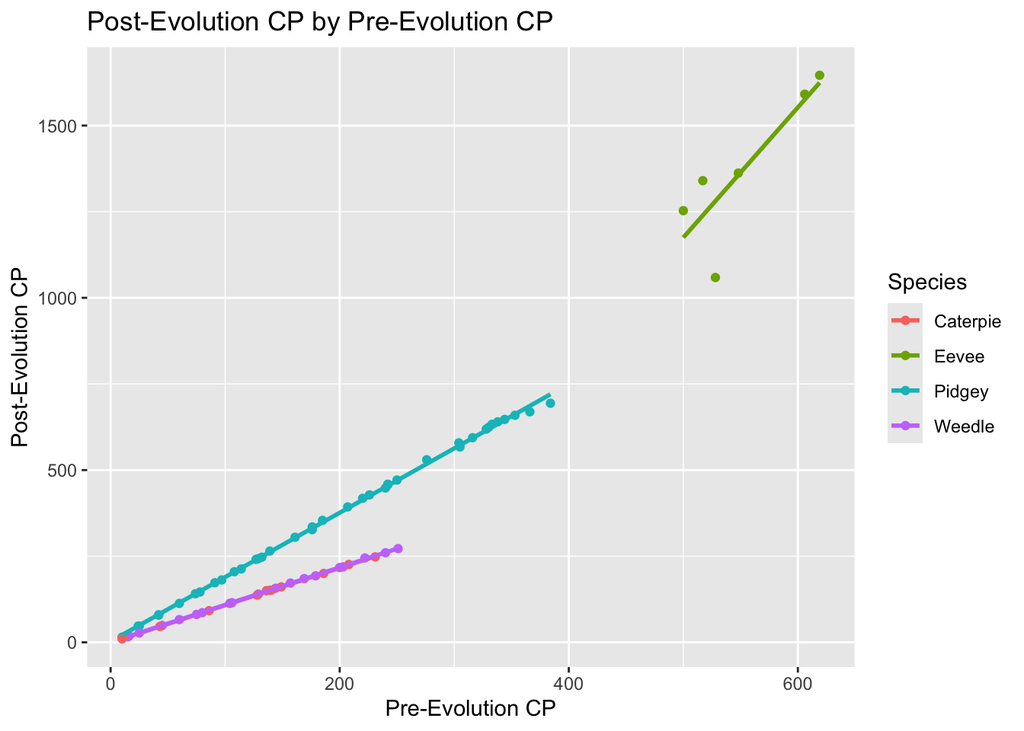

```r
pokemon_go |>
  ggplot(aes(x = cp, y = cp_new, color = species)) +
  geom_point() +
  geom_smooth(method = "lm", se = FALSE) +
  labs(x = "Pre-Evolution CP",
       y = "Post-Evolution CP",
       color = "Species",
       title = "Post-Evolution CP by Pre-Evolution CP")
```

## Final Analysis

This figure shows a strong positive relationship between pre-evolution CP and post-evolution CP. Overall, the Pokemon with the higher CP before evolution also have higher CP after evolution, which supports the idea that pre-evolution CP is.a useful predictor of post-evolution of CP.

The figure suggests that species matters. Eevee is shown to have a much higher CP value than other species. Pidgey has a higher trend than both Weedle and Caterpie, which share similar CP values.

Based off this figure, we have reason to believe this relationship because the trend clearly point in an upward trend which is expected in post-evolution CP values.

Overall, this result supports the hypothesis that higher pre-evolution CP is associated with higher post-evolution CP. As well as this, it suggests that the relationship is different per species so including the interaction between `cp` and `species` is useful.

# Discussion

The results support my hypothesis that Pokemon with higher pre-evolution CP usually also have higher post-evolution CP.

Species is shown to be important because the CP patter is different among different Pokemon species. An example of this is Eevee having much higher CP values than Caterpie and Weedle.

This finding is useful because players may use pre-evolution CP ot help decide which Pokemon are worth evolving and keeping.

One limitation of the date that is shown is that the data only has 75 evolutions and only 4 species, so the results may not apply to all Pokemon. A better future analysis would include a data set with more species.